# 基于微博数据的银行相关舆情分析

使用Python爬虫脚本采集新浪微博上与银行相关的博文文本数据。通过对文本数据进行清洗、情感识别、可视化展示等对公众舆情中的银行槽点、各个银行情感倾向进行分析从而挖掘并了解大众对四大行的主要印象。本次分析内容主要包含以下几点：  
1）、银行槽点分析（词云可视化展示）  
2）、银行相关微博情感倾向分析  
3）、四大行舆情口碑评分  
4）、四大行舆情热点挖掘（词云可视化展示）

```python
import os
os.chdir(r'E:\建行专题分析报告')
```

```python
import pandas as pd
import numpy as np
import pyecharts
import matplotlib.pyplot as plt
import warnings
import matplotlib.image as mpimg
%matplotlib inline
warnings.filterwarnings("ignore")
```

## 一、导入数据

```python
data_all=pd.DataFrame()
for i in os.listdir(r'文本数据'):
    data_tmp=pd.read_excel(r'文本数据\\'+i)
    data_all=data_all.append(data_tmp)
```

```python
data_all.head()
```

|  | 微博内容 |
| --- | --- |
| 0 | 真的想吐槽中国银行。没得哪一回是速战速决的。2.36就在这坐。就办个转账。搞毛哦！ 大胖薇的... |
| 1 | 还是国有四大行的银行卡好用，不想再多吐槽什么了，坑的一批 |
| 2 | 垃圾招商银行@招商银行 |
| 3 | 真心不想吐槽中国邮政储蓄银行的 但是也太恶心了吧！我明明三年前就注销了的卡 为什么这次去查询... |
| 4 | 中国农业银行的电话服务让人无语……\n首先，经过三层难关进入了人工客服服务，被告知人多太忙，... |

## 二、文本清洗

由于网络数据并不规范，存在各种数据质量问题，在进行分析之前必须进行文本清洗。主要清洗工作有：  
1）、大小写转换  
2）、繁简体转换  
3）、全角转半角

```python
#导入自定义模块
import zh_wiki as ZH
from langconv import *
```

```python
## 文本处理
#大小写转换
def lower(X):
    """ 大小写转换
    参数
    ----
    X: Series
    """
    X = X.str.lower()
    return X

#繁简体转换
def traditional2simple(X):
    """ 繁体转简体
    参数
    ----
    X: Series
    """
    X = X.apply(lambda x: Converter('zh-hans').convert(x))
    return X

#全角转半角
def FullToHalf(s):
    n = []
    for char in s:
        num = ord(char)#ord用于返回ascii码
        if num == 0x3000:
            num = 32
        elif 0xFF01 <= num <= 0xFF5E:   #修正全角ascii码
            num -= 0xfee0
        num = chr(num)#chr用于解析ascii码
        n.append(num)
    return ''.join(n)
```

```python
data_all['微博内容']=lower(data_all['微博内容'])
data_all['微博内容']=traditional2simple(data_all['微博内容'])
data_all['微博内容']=data_all['微博内容'].map(lambda x : FullToHalf(x))
```

## 三、银行槽点分析

银行槽点分析主要对用户对银行吐槽类微博进行分词等数据处理并构造直观的词云展示，主要步骤如下：  
1）、筛选包含“吐槽”二字的微博  
2）、对其进行结巴分词、去停用词等处理  
3）、进行槽点统计与可视化展示（词云）

### 3.1 吐槽数据筛选

```python
#导入模块
import pickle
from os import path
import jieba
from wordcloud import WordCloud, STOPWORDS,ImageColorGenerator
```

```python
data_tucao=data_all[data_all['微博内容'].str.contains('吐槽')]
```

### 3.2 词云可视化展示

```python
def draw_wordcloud(data_df,background,dir_name,color,rcParams):
    global wl_space_split
    #### 结巴分词#####
    #导入词典
    jieba.load_userdict(r"dict_input.txt")
    #导入停用词
    stop_words = pd.read_table("stop_words.txt",header=None)
    stopwords = set(stop_words[0])
    CON=data_df['微博内容']
    seg_list = []
    for con in CON:
        seg = jieba.lcut(con,cut_all=False)
        seg_clear = set(seg)-stopwords
        seg_clear_str = ",".join(list(seg_clear))
        seg_list.append(seg_clear_str)
    wl_space_split=",".join(seg_list)
    wl_space_split=re.sub(r'\[.*?\]','',wl_space_split)
    wl_space_split=re.sub(r'\#.*?\#','',wl_space_split)
    #导入屏蔽词
    stopword_ls=[]
    with open(r'stop_words.txt','r',encoding='utf-8') as f:
        stopword_ls=(f.readlines())
        stopword_ls=[i.replace('\n','').replace('\ufeff','')  for i in stopword_ls]
    #导入背景图
    backgroud_Image = plt.imread(background)
    stopwords = STOPWORDS.copy()
    #可以加多个屏蔽词
    for i in stopword_ls:
        stopwords.add(i)

    #### 设置词云参数 ####
    #参数分别是指定字体、背景颜色、最大的词的大小、使用给定图作为背景形状
    wc =WordCloud(width=4048,height=1632,background_color=color,  mask=backgroud_Image,font_path="C:\simhei.ttf",
        stopwords=stopwords,max_font_size=80,
        random_state=10)
    wc.generate_from_text(wl_space_split)
    img_colors=ImageColorGenerator(backgroud_Image)
    wc.recolor(color_func=img_colors)
    plt.imshow(wc)
    plt.axis('off')#不显示坐标轴
    plt.rcParams['figure.dpi'] = rcParams #分辨率
    plt.figure(figsize=(20,16))
    plt.show()
    #保存结果到本地
    wc.to_file(dir_name)
```

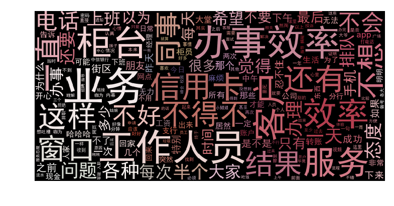

```python
draw_wordcloud(data_tucao,'词云背景2.jpg','吐槽2.jpg','black',150)
```

## 四、微博情感分析

1)、调用百度AI情感识别接口进行分类  
2)、分别统计四大行好评与差评情况  
3)、可视化展示

### 4.1 情感倾向识别

```python
import pandas as pd
import datetime
from aip import AipNlp
import codecs
```

```python
##正则过滤表情符号
def clean_em(text):
    """使用编码范围清除表情，如：🙃👧👍"""
    emoji_pattern1 = re.compile("["u"\U0001F600-\U0001F64F"  # emoticons
                                           u"\U0001F300-\U0001F5FF"  # symbols & pictographs
                                           u"\U0001F680-\U0001F6FF"  # transport & map symbols
                                           u"\U0001F1E0-\U0001F1FF"  # flags (iOS)
                                           u"\U0001f926-\U0001f937"
                                           u"\uD800-\uDBFF"
                                           u"\uDC00-\uDFFF"
                                                              "]+", flags=re.UNICODE)
    nickname = emoji_pattern1.sub(u'',text)
    return nickname
#由于百度ai接口要求gbk编码格式，需要删除无法转码的字符串
def  killAnUnseen(s):
    try:
        s.encode('gbk')
    except UnicodeEncodeError as err:
        info = str(err);
        st = re.search('\\\\U[a-f0-9]{8}|\\\\u[a-f0-9]{4}|\\\\x[a-f0-9]{2}', info).group()[2:];
        x = int(st, 16)
        s=s.replace(chr(x), "")
    return s
```

```python
#表情清除示例
clean_em('再次为建行的服务态度👧，内部环境，服务质量点个大大的赞👍👍👍建设银行 ')
```

```
'再次为建行的服务态度，内部环境，服务质量点个大大的赞建设银行 '
```

```python
data_all['微博内容']=data_all['微博内容'].map(clean_em)
data_all['微博内容']=data_all['微博内容'].map(killAnUnseen)
```

```python
#定义函数用于接入百度ai接口
## 百度api信息，请到百度ai官方网站注册申请
APP_ID = '百度AI平台申请ID'
API_KEY = '百度AI平台申请API_KEY'
SECRET_KEY = '百度AI平台申请SECRET_KEY'
client = AipNlp(APP_ID, API_KEY, SECRET_KEY)
def get_sentiment(text):
    try:
        sitems=client.sentimentClassify(text)['items'][0]#情感分析
    except:
        sitems={'confidence': 0,
   'negative_prob': 0,
   'positive_prob': 0,
   'sentiment': '无结果'}
    time.sleep(1)
    return sitems
```

```python
data_all['sitems']=data_all['微博内容'].map(get_sentiment)
data_all['情感倾向']=data_all['sitems'].map(lambda x : str(x['sentiment'])  )
data_use=data_all[data_all['情感倾向']!='无结果']
```

```python
#结果展示:2为正面，0为负面，1为中性
data_use.head(5)
```

|  | 微博内容 | sitems | 情感倾向 |
| --- | --- | --- | --- |
| 0 | 北京银行的APP终于适配iPhone X，可以用面容ID解锁了……这效率真是刚刚的——机子都... | {'positive_prob': 0.202031, 'confidence': 0.55... | 2 |
| 1 | 妈呀 民生银行这个效率 | {'positive_prob': 0.485026, 'confidence': 0.70... | 0 |
| 2 | 现在银行办事效率好高，10多分钟就办理好所有事情。上班来早，来KFC罪过～ | {'positive_prob': 0.627853, 'confidence': 0.17... | 2 |
| 3 | 杭州银行这破银行，效率真是太低太低太低了！！！以后都不想来了，什么玩意儿，想骂人 | {'positive_prob': 0.263564, 'confidence': 0.41... | 0 |
| 4 | 前几天两家银行一定是看我信用卡刷了10k……不停打电话过来问要不要贷款 月底的时候还有两位广... | {'positive_prob': 0.770712, 'confidence': 0.49... | 1 |

```python
data_use.to_excel(r'情感倾向.xlsx')#导出备份
```

### 4.2 统计分析

1)、情感倾向正负面占比  
2)、四大行口碑得分  
3)、四大行舆情关注点（词云展示）

#### 4.2.1 情感倾向占比

```python
import pyecharts as Pc
attr=['负面','正面','中性']
v1=list(data_use['情感倾向'].value_counts())
pie=Pc.Pie('情感倾向占比',title_pos='center',width=900)
pie.add('情感',attr,v1,center=[50,50],is_random=True,radius=[30,75],rosetype='area',is_legend_show=False
       ,is_label_show=True)
pie
```

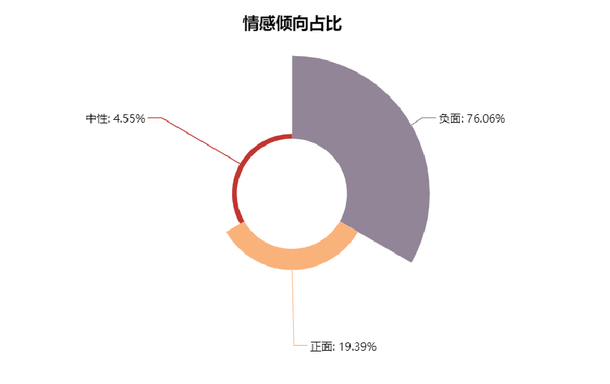

```python
lena = mpimg.imread('情感倾向占比2.jpg') #读取和代码处于同一目录下的lena.png
plt.imshow(lena) # 显示图片
plt.axis('off') # 不显示坐标轴
plt.rcParams['figure.figsize'] = (15, 30) # 设置figure_size尺寸
plt.show()
```

#### 4.2.2 四大银行的口碑得分情况

对四大行口碑进行评分。其中正面评价得2分、负面评价得0分，中性评价得1分，以均值乘以200作为最终得分

```python
data_cbc=data_use[(data_use['微博内容'].str.contains('建设银行'))|(data_use['微博内容'].str.contains('建行'))]
data_abc=data_use[(data_use['微博内容'].str.contains('农业银行'))|(data_use['微博内容'].str.contains('农行'))]
data_icbc=data_use[(data_use['微博内容'].str.contains('工商银行'))|(data_use['微博内容'].str.contains('工行'))]
data_bc=data_use[data_use['微博内容'].str.contains('中国银行')]
```

```python
#以平均值作为得分，由于量纲不同乘以200作为最终得分
score_cbc=int(data_cbc['情感倾向'].map(int).mean()*200)
score_abc=int(data_abc['情感倾向'].map(int).mean()*200)
score_icbc=int(data_icbc['情感倾向'].map(int).mean()*200)
score_bc=int(data_bc['情感倾向'].map(int).mean()*200)
```

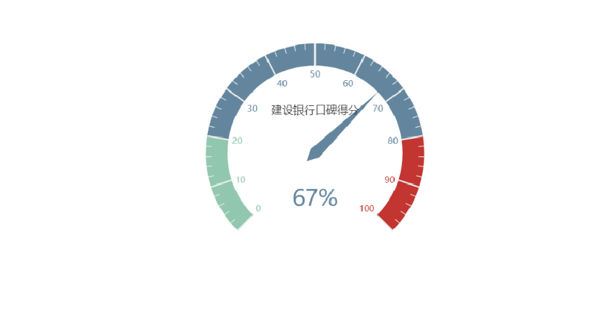

```python
from pyecharts import Gauge
gauge =Gauge()
gauge.add("", "建设银行口碑得分",score_cbc)
gauge
```

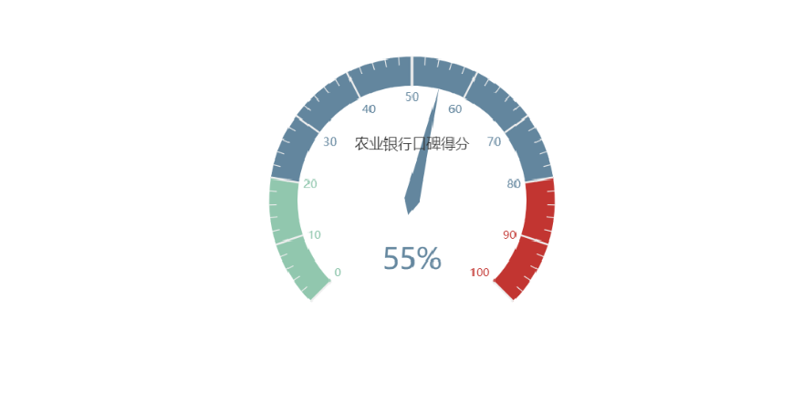

```python
gauge =Gauge()
gauge.add("", "农业银行口碑得分",score_abc)
gauge
```

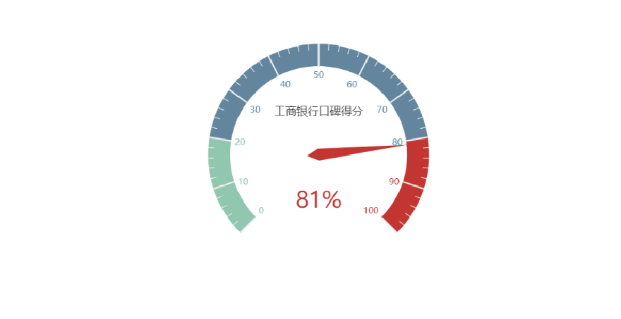

```python
gauge =Gauge()
gauge.add("", "工商银行口碑得分",score_icbc)
gauge
```

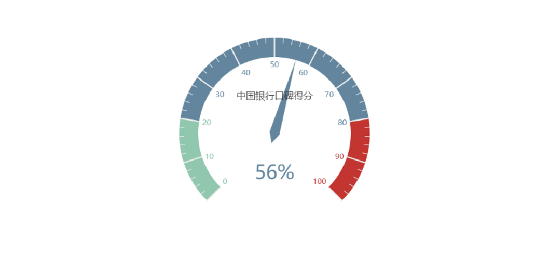

```python
gauge =Gauge()
gauge.add("", "中国银行口碑得分",score_bc)
gauge
```

#### 4.2.3 四大行微博舆情关注点（词云展示）

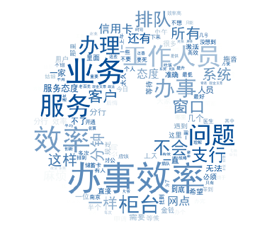

```python
#建设银行
draw_wordcloud(data_cbc,'建行logo3.jpg','建设银行舆情词云.jpg','white',100)
```

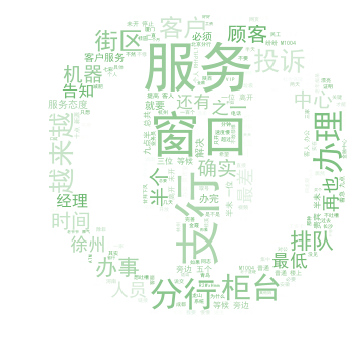

```python
#农业银行
draw_wordcloud(data_abc,'农业银行logo4.jpg','农业银行舆情词云.jpg','white',100)
```

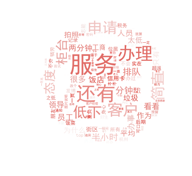

```python
#工商银行
draw_wordcloud(data_icbc,'工行logo4.jpg','工商银行舆情词云.jpg','white',100)
```

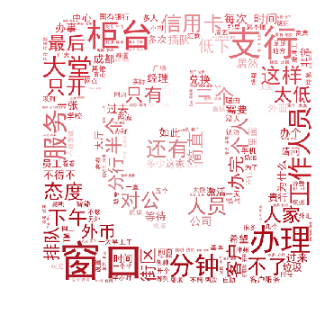

```python
#中国银行
draw_wordcloud(data_bc,'中国银行logo2.jpg','中国银行舆情词云.jpg','white',100)
```

## 五、总结

经过上述分析，我们可清晰得到以下几个结论：

#### 1、新浪微博上公开对银行的舆情情感倾向偏负面；

#### 2、新浪微博上大多数对银行吐槽槽点为：办事效率慢、柜员态度较差、经常排队、APP不人性化等；

#### 3、四大行在新浪微博上舆情口碑得分排名如下（从高到低）：1、工商银行，2、建设银行，3、中国银行，4、农业银行；

#### 4、新浪微博上对四大行讨论热点基本相同，主要集中在：柜台、工作人员、窗口、信用卡等。